# Домашнее задание по RLMS

AAБB-команда

30 April 2015

### *Исследователь Вениамин только начал изучать R, и для него это первое исследование, сделанное в таком формате. Поэтому не судите, пожалуйста, его строго :) Рассмотрим по шагам каждое его действие*

Загрузим все пакеты для работы.

```r
library("pander")
library("knitr")
library("lmtest")
library("psych")
library("memisc")
library("psych")
library("dplyr")
library("knitr")
library("rlms")
library("sandwich")
library("ggplot2")
library("scales")
```

Зададим директорий и подгрузим данные.

```r
setwd("~/Desktop")
df <- read.rlms("r22i_os25a.sav")
```

Подготовим данные к анализу и выберем переменные.

```r
data <- mutate(df,
sex = as.numeric(rh5=="МУЖСКОЙ"),
age = 2013-rh6,
wage = rj13.2,
educ_l = as.numeric(as.numeric(r_diplom)<4),
educ_m = as.numeric(as.numeric(r_diplom)==4),
educ_ms = as.numeric(as.numeric(r_diplom)==5),
educ_h = as.numeric(as.numeric(r_diplom)==6),
city = as.numeric(as.numeric(status)<3),
udovl = as.numeric(as.numeric(rj1.1.1)<3)) %>%
dplyr::select(sex, age, wage, educ_l, educ_m, educ_ms, educ_h,
city, udovl)
```

Соберём наш прекрасный массив :)

Посмотрим быстро на описание массива. Отберём некоторые характеристики.

```r
desc <- describe(data) # from psych package
desc_selected <- as.data.frame(desc[,c(1,2,3,4,5)]) # not all statistics
pander(desc_selected)
```

|  | vars | n | mean | sd | median |
| --- | --- | --- | --- | --- | --- |
| **sex** | 1 | 16087 | 0.4317 | 0.4953 | 0 |
| **age** | 2 | 16087 | 40.07 | 22.5 | 40 |
| **wage** | 3 | 6080 | 19791 | 15937 | 16000 |
| **educ_l** | 4 | 13595 | 0.2029 | 0.4022 | 0 |
| **educ_m** | 5 | 13595 | 0.3227 | 0.4675 | 0 |
| **educ_ms** | 6 | 13595 | 0.2359 | 0.4246 | 0 |
| **educ_h** | 7 | 13595 | 0.236 | 0.4247 | 0 |
| **city** | 8 | 16087 | 0.6646 | 0.4721 | 1 |
| **udovl** | 9 | 7294 | 0.6715 | 0.4697 | 1 |

Это можно также сделать с помощью другой команды.

```r
summary(data)
```

```
##       sex              age              wage            educ_l
##  Min.   :0.0000   Min.   :  0.00   Min.   :     0   Min.   :0.0000
##  1st Qu.:0.0000   1st Qu.: 22.00   1st Qu.: 10000   1st Qu.:0.0000
##  Median :0.0000   Median : 40.00   Median : 16000   Median :0.0000
##  Mean   :0.4317   Mean   : 40.07   Mean   : 19791   Mean   :0.2029
##  3rd Qu.:1.0000   3rd Qu.: 58.00   3rd Qu.: 25000   3rd Qu.:0.0000
##  Max.   :1.0000   Max.   :100.00   Max.   :300000   Max.   :1.0000
##                                    NA's   :10007    NA's   :2492
##      educ_m          educ_ms           educ_h           city
##  Min.   :0.0000   Min.   :0.0000   Min.   :0.000   Min.   :0.0000
##  1st Qu.:0.0000   1st Qu.:0.0000   1st Qu.:0.000   1st Qu.:0.0000
##  Median :0.0000   Median :0.0000   Median :0.000   Median :1.0000
##  Mean   :0.3227   Mean   :0.2359   Mean   :0.236   Mean   :0.6646
##  3rd Qu.:1.0000   3rd Qu.:0.0000   3rd Qu.:0.000   3rd Qu.:1.0000
##  Max.   :1.0000   Max.   :1.0000   Max.   :1.000   Max.   :1.0000
##  NA's   :2492     NA's   :2492     NA's   :2492
##      udovl
##  Min.   :0.000
##  1st Qu.:0.000
##  Median :1.000
##  Mean   :0.672
##  3rd Qu.:1.000
##  Max.   :1.000
##  NA's   :8793
```

Так как задание сделано в учебных целях, облегчим себе жизнь и очистим данные от пропусков.

```r
data<-na.omit(data)
```

Изобразим пару графиков (вариант 1).

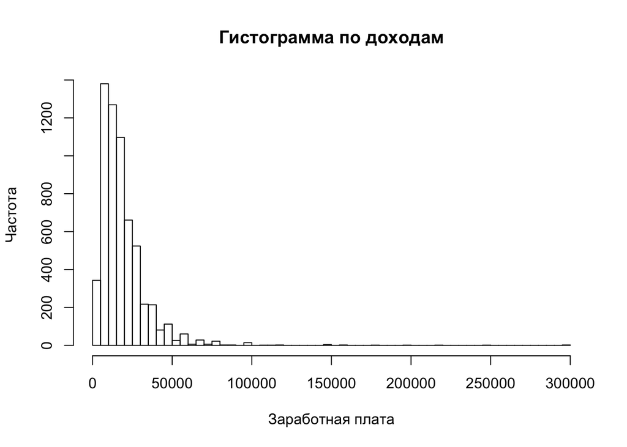

```r
hist(data$wage,breaks = 50, main = "Гистограмма по доходам", xlab="Заработная плата", ylab="Частота")
```

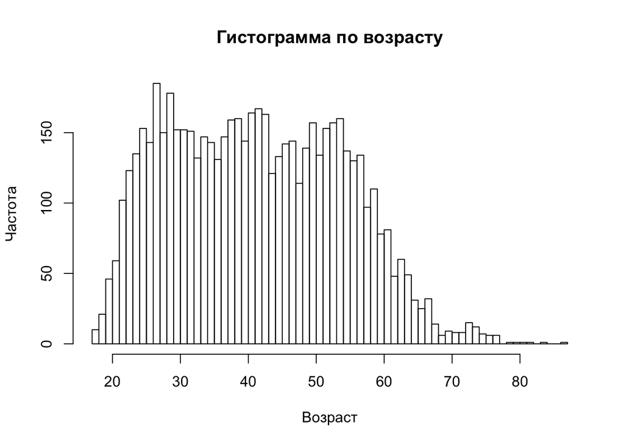

```r
hist(data$age,breaks = 50, main = "Гистограмма по возрасту", xlab="Возраст", ylab="Частота")
```

А теперь изобразим пару более красивых графиков (вариант 2).

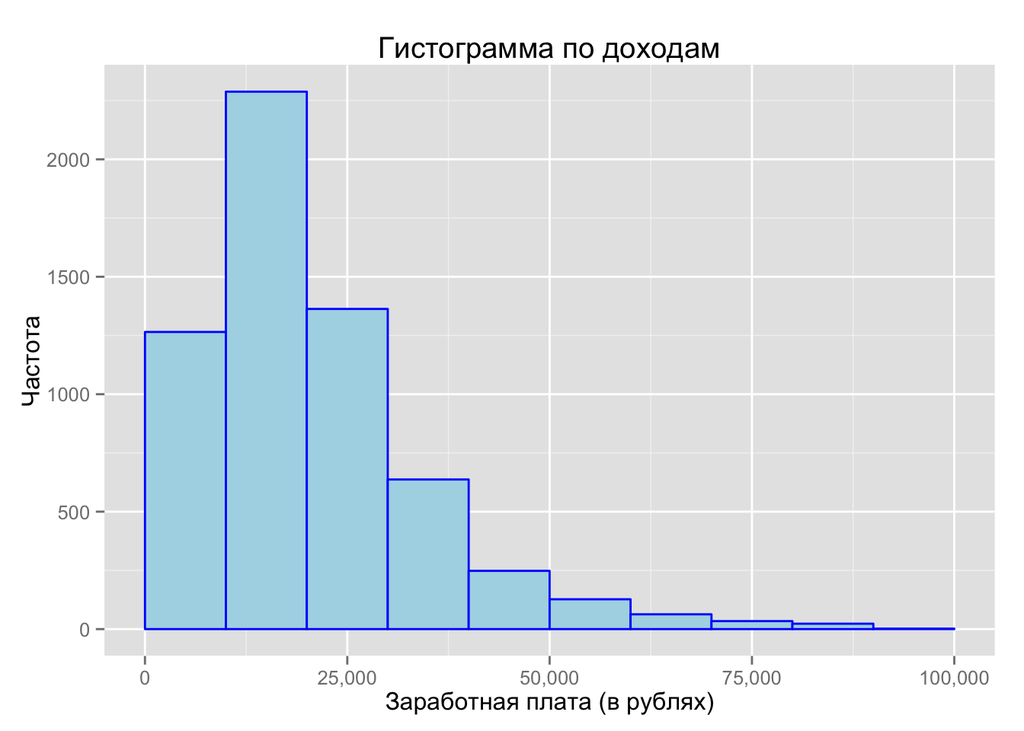

```r
ggplot(data=data, aes(wage)) + geom_histogram(binwidth=10000, fill="lightblue", color="blue") + labs(title = "Гистограмма по доходам", x="Заработная плата (в рублях)", y="Частота")+scale_x_continuous(limits=c(0,100000),labels=comma)
```

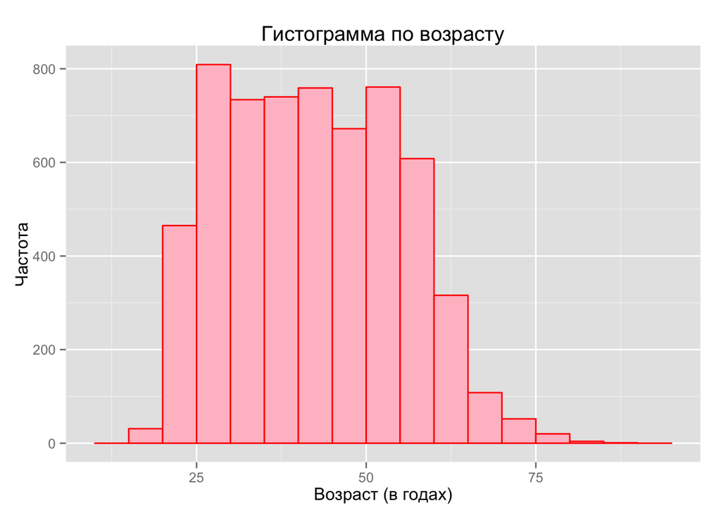

```r
ggplot(data=data, aes(age)) + geom_histogram(fill="pink",binwidth=5, color="red") + labs(title = "Гистограмма по возрасту", x="Возраст (в годах)", y="Частота")
```

Оценим модель и посмотрим на коэффициенты.

```r
model<-lm(wage ~ sex + age + educ_m + educ_ms + educ_h + city + udovl, data = data)
```

Для начинающих такая табличка сойдёт :)

```r
summary(model)
```

```
##
## Call:
## lm(formula = wage ~ sex + age + educ_m + educ_ms + educ_h + city +
##     udovl, data = data)
##
## Residuals:
##    Min     1Q Median     3Q    Max
## -30301  -7973  -2504   4478 286904
##
## Coefficients:
##             Estimate Std. Error t value Pr(>|t|)
## (Intercept)  8189.57     971.19   8.433  < 2e-16 ***
## sex          8244.06     386.19  21.347  < 2e-16 ***
## age           -81.91      14.96  -5.474 4.56e-08 ***
## educ_m       2148.54     716.16   3.000  0.00271 **
## educ_ms      4153.31     735.15   5.650 1.68e-08 ***
## educ_h      10245.77     726.09  14.111  < 2e-16 ***
## city         5051.10     420.47  12.013  < 2e-16 ***
## udovl        3782.18     404.98   9.339  < 2e-16 ***
## ---
## Signif. codes:  0 '***' 0.001 '**' 0.01 '*' 0.05 '.' 0.1 ' ' 1
##
## Residual standard error: 14660 on 6072 degrees of freedom
## Multiple R-squared:  0.1549, Adjusted R-squared:  0.1539
## F-statistic: 158.9 on 7 and 6072 DF,  p-value: < 2.2e-16
```

Но для красоты можно сделать так:

```r
coefs <- coeftest(model)
pander(coefs[,1:4])
```

|  | Estimate | Std. Error | t value | Pr(>\|t\|) |
| --- | --- | --- | --- | --- |
| **(Intercept)** | 8190 | 971.2 | 8.433 | 4.183e-17 |
| **sex** | 8244 | 386.2 | 21.35 | 1.488e-97 |
| **age** | -81.91 | 14.96 | -5.474 | 4.564e-08 |
| **educ_m** | 2149 | 716.2 | 3 | 0.00271 |
| **educ_ms** | 4153 | 735.1 | 5.65 | 1.681e-08 |
| **educ_h** | 10246 | 726.1 | 14.11 | 1.633e-44 |
| **city** | 5051 | 420.5 | 12.01 | 7.154e-33 |
| **udovl** | 3782 | 405 | 9.339 | 1.332e-20 |

Основной вывод: все коэффициенты значимы. Все p-значения очень маленькие, то есть нулевая гипотеза ($H_0: \beta_i = 0$) при проверке гипотезы о значимости для каждого отдельного коэффициента отвергается. Вспомним два важных момента для интерпретации:

1. Если переменная числовая и коэффициент при ней значим и, скажем, положителен, то увеличение этого показателя на одну единицу будет вызывать увеличение заработной платы на $\hat{\beta}_i$ при этой переменной.
2. Если переменная факторная и коэффициент при ней значим, то $\hat{\beta}_i$ при этой переменной будет означать, что заработная плата будет изменяться на $\hat{\beta}_i$ при переходе от базовой категории этой переменной к той категории, которая у нас отображена перед $\hat{\beta}_i$.

А теперь с робастными ошибками.

```r
coefs2 <- coeftest(model, vcov. = vcovHC(model))
pander(coefs2[,1:4])
```

|  | Estimate | Std. Error | t value | Pr(>\|t\|) |
| --- | --- | --- | --- | --- |
| **(Intercept)** | 8190 | 819.8 | 9.99 | 2.551e-23 |
| **sex** | 8244 | 421.5 | 19.56 | 1.183e-82 |
| **age** | -81.91 | 13.61 | -6.02 | 1.846e-09 |
| **educ_m** | 2149 | 461 | 4.661 | 3.218e-06 |
| **educ_ms** | 4153 | 503.4 | 8.25 | 1.928e-16 |
| **educ_h** | 10246 | 570.2 | 17.97 | 2.206e-70 |
| **city** | 5051 | 348.1 | 14.51 | 6.414e-47 |
| **udovl** | 3782 | 355.3 | 10.65 | 3.092e-26 |

Выводы не меняются. Все коэффициенты значимы, но стадартные отклонения теперь изменились.

В заключении хотим сказать, что это краткий пример того, что можно было сделать. Мы специально не стали накручивать, потому что понимаем, что само выполнение домашнего задания вызывает сложность, поэтому мы не требуем повышенного качества :)